# Modeling and Inference in R

Deirdre Fitzpatrick & Dana Udwin

July 26, 2016

# Sponsors

[figure not shown]

[figure not shown]

& Western Mass Statistics and Data Science Meetup

# Follow Along

http://tinyurl.com/j3vqd5z

# Introduction

Modeling in R consists of:

- formula object
  - `Sepal.Length ~ Sepal.Width`
  - Use `Sepal.Width` to predict `Sepal.Length`
- model object
  - `lm()`
  - Put your formula inside of `lm()`
- observing your model
  - `anova()`, `plot()` or `summary()`
  - Put your model inside of `plot()`

# Simple Linear Regression (SLR)

- Linear relationship between variables
  - i.e. as `Sepal.Width` increases, we think `Sepal.Length` does, too (in a nice straight line)
- Response variable is continuous
  - `Sepal.Length` is numeric (not categories like “short” or “long”)
- “Simple” = only one explanatory variable

# Preview the Data

```r
# ?swiss
head(swiss)
```

```
##              Fertility Agriculture Examination Education Catholic
## Courtelary        80.2        17.0          15        12     9.96
## Delemont          83.1        45.1           6         9    84.84
## Franches-Mnt      92.5        39.7           5         5    93.40
## Moutier           85.8        36.5          12         7    33.77
## Neuveville        76.9        43.5          17        15     5.16
## Porrentruy        76.1        35.3           9         7    90.57
##              Infant.Mortality
## Courtelary               22.2
## Delemont                 22.2
## Franches-Mnt             20.2
## Moutier                  20.3
## Neuveville               20.6
## Porrentruy               26.6
```

# Eyeball the Data

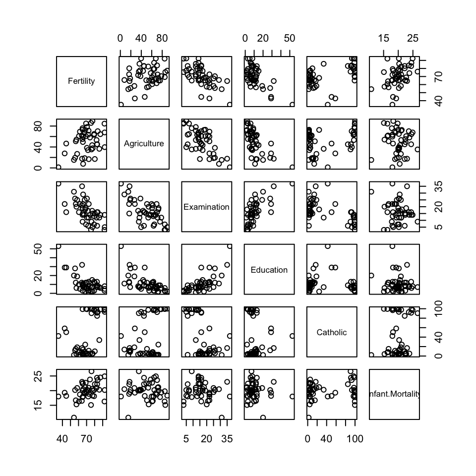

```r
plot(swiss)
```

# Fit the SLR Model

```r
mdl <- lm(Agriculture ~ Examination, data=swiss)
```

- response or dependent variable = Agriculture
  - the thing we want to predict
- explanatory or independent variable = Examination

# Summarize Model

```r
summary(mdl)
```

```
##
## Call:
## lm(formula = Agriculture ~ Examination, data = swiss)
##
## Residuals:
##     Min      1Q  Median      3Q     Max
## -36.570 -10.781   2.575  11.871  29.411
##
## Coefficients:
##             Estimate Std. Error t value Pr(>|t|)
## (Intercept)  82.8869     5.6407  14.694  < 2e-16 ***
## Examination  -1.9544     0.3086  -6.334 9.95e-08 ***
## ---
## Signif. codes:  0 '***' 0.001 '**' 0.01 '*' 0.05 '.' 0.1 ' ' 1
##
## Residual standard error: 16.7 on 45 degrees of freedom
## Multiple R-squared:  0.4713, Adjusted R-squared:  0.4596
## F-statistic: 40.12 on 1 and 45 DF,  p-value: 9.952e-08
```

Agriculture = 82.8868674 - 1.9544294 Examination + $\epsilon$

(You get lots of asterisks next to significant variables.)

# Analysis of Variance

```r
anova(mdl)
```

```
## Analysis of Variance Table
##
## Response: Agriculture
##             Df Sum Sq Mean Sq F value    Pr(>F)
## Examination  1  11183 11183.4  40.121 9.952e-08 ***
## Residuals   45  12543   278.7
## ---
## Signif. codes:  0 '***' 0.001 '**' 0.01 '*' 0.05 '.' 0.1 ' ' 1
```

# Check Out Residuals

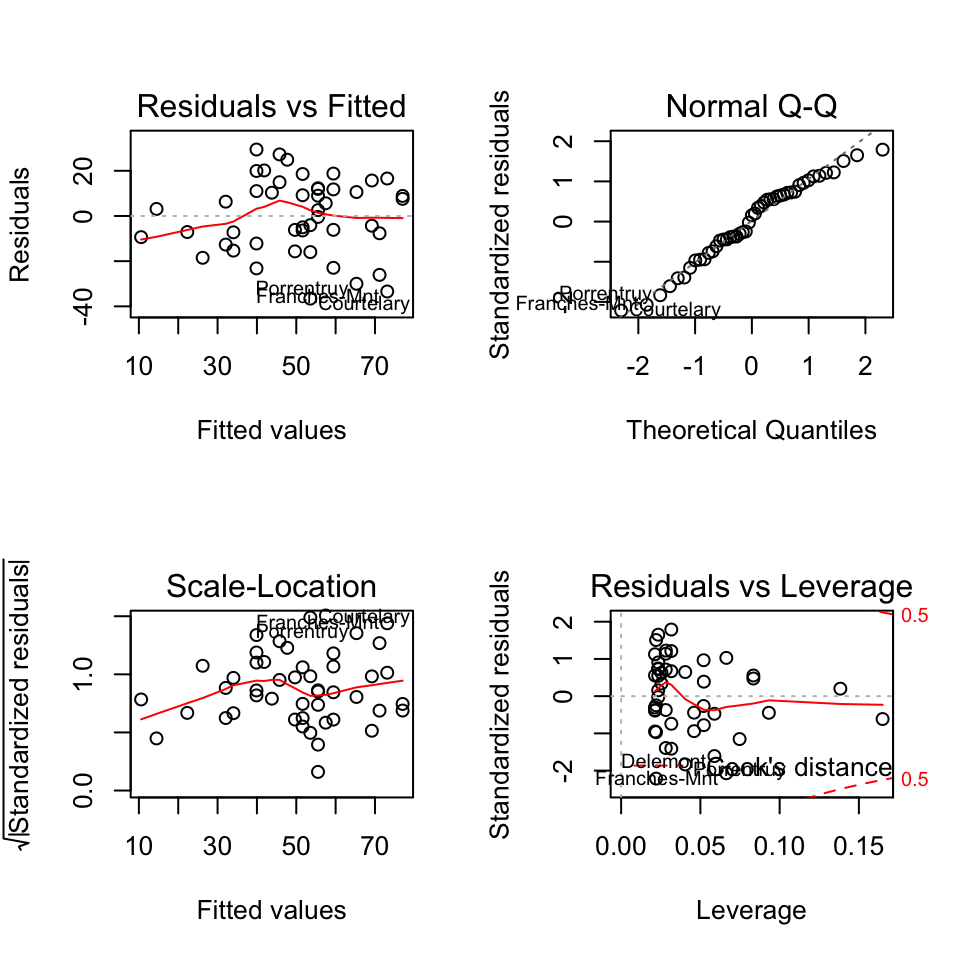

```r
par(mfrow=c(2,2))
plot(mdl)
```

# Or, Try It Without an Intercept!

```r
mdl <- lm(Agriculture ~ Examination - 1, data=swiss)
mdl <- lm(Agriculture ~ Examination + 0, data=swiss)

summary(mdl)
```

```
##
## Call:
## lm(formula = Agriculture ~ Examination + 0, data = swiss)
##
## Residuals:
##     Min      1Q  Median      3Q     Max
## -77.806   0.812  20.129  35.688  79.494
##
## Coefficients:
##             Estimate Std. Error t value Pr(>|t|)
## Examination   2.1353     0.3173    6.73 2.32e-08 ***
## ---
## Signif. codes:  0 '***' 0.001 '**' 0.01 '*' 0.05 '.' 0.1 ' ' 1
##
## Residual standard error: 39.76 on 46 degrees of freedom
## Multiple R-squared:  0.4961, Adjusted R-squared:  0.4852
## F-statistic: 45.29 on 1 and 46 DF,  p-value: 2.317e-08
```

# Rewind

What even is an `lm()`?

[figure not shown]

# About the Model Object

```r
names(mdl)
```

```
##  [1] "coefficients"  "residuals"     "effects"       "rank"
##  [5] "fitted.values" "assign"        "qr"            "df.residual"
##  [9] "xlevels"       "call"          "terms"         "model"
```

```r
mdl['coefficients']
```

```
## $coefficients
## Examination
##    2.135296
```

# And Plays Well with Others

```r
# sample 5 numbers from the uniform distribution (0, 100)
fake_data <- data.frame(Examination = runif(5, 0, 100))

predict(mdl, newdata=fake_data, interval="confidence")
```

```
##         fit       lwr       upr
## 1  5.068688  3.552707  6.584669
## 2 15.574130 10.916102 20.232157
## 3 42.449110 29.753112 55.145107
## 4 70.772823 49.605558 91.940089
## 5 24.830377 17.403922 32.256832
```

# More Nice Playing

```r
r <- residuals(mdl)
head(r)
```

```
##   Courtelary     Delemont Franches-Mnt      Moutier   Neuveville
##   -15.029445    32.288222    29.023518    10.876444     7.199962
##   Porrentruy
##    16.082333
```

```r
coef(mdl)
```

```
## Examination
##    2.135296
```

```r
f <- fitted(mdl)
head(f)
```

```
##   Courtelary     Delemont Franches-Mnt      Moutier   Neuveville
##     32.02945     12.81178     10.67648     25.62356     36.30004
##   Porrentruy
##     19.21767
```

# Working Example

```r
# install.packages('ggplot2')
require(ggplot2)

head(diamonds)
```

```
##   carat       cut color clarity depth table price    x    y    z
## 1  0.23     Ideal     E     SI2  61.5    55   326 3.95 3.98 2.43
## 2  0.21   Premium     E     SI1  59.8    61   326 3.89 3.84 2.31
## 3  0.23      Good     E     VS1  56.9    65   327 4.05 4.07 2.31
## 4  0.29   Premium     I     VS2  62.4    58   334 4.20 4.23 2.63
## 5  0.31      Good     J     SI2  63.3    58   335 4.34 4.35 2.75
## 6  0.24 Very Good     J    VVS2  62.8    57   336 3.94 3.96 2.48
```

# Lines of Inquiry

- Use `lm()` to model price as a function of carat.
- Find the coefficients. (Are they significant?)
- Use your model with `predict()` to predict the price of diamonds with 0.5, 2 and 0.73 carats, respectively.

```r
# hint, use this fresh dataframe
# with the newdata argument inside of predict()
fresh_diamonds <- data.frame(carat = c(0.5, 2, 0.73))
```

Type `?lm` or `?predict` in your console for more info!

# One Way to Answer

```r
mdl <- lm(price ~ carat, data=diamonds)

summary(mdl)
```

```
##
## Call:
## lm(formula = price ~ carat, data = diamonds)
##
## Residuals:
##      Min       1Q   Median       3Q      Max
## -18585.3   -804.8    -18.9    537.4  12731.7
##
## Coefficients:
##             Estimate Std. Error t value Pr(>|t|)
## (Intercept) -2256.36      13.06  -172.8   <2e-16 ***
## carat        7756.43      14.07   551.4   <2e-16 ***
## ---
## Signif. codes:  0 '***' 0.001 '**' 0.01 '*' 0.05 '.' 0.1 ' ' 1
##
## Residual standard error: 1549 on 53938 degrees of freedom
## Multiple R-squared:  0.8493, Adjusted R-squared:  0.8493
## F-statistic: 3.041e+05 on 1 and 53938 DF,  p-value: < 2.2e-16
```

```r
fresh_diamonds <- data.frame(carat = c(0.5, 2, 0.73))
predict(mdl, newdata=fresh_diamonds)
```

```
##         1         2         3
##  1621.852 13256.491  3405.830
```

# Multiple Linear Regression

- Response variable is still continuous
- Two or more independent explanatory variables
- Let’s model fertility using Catholic and Education as predictors

# Check Independence Between Predictors

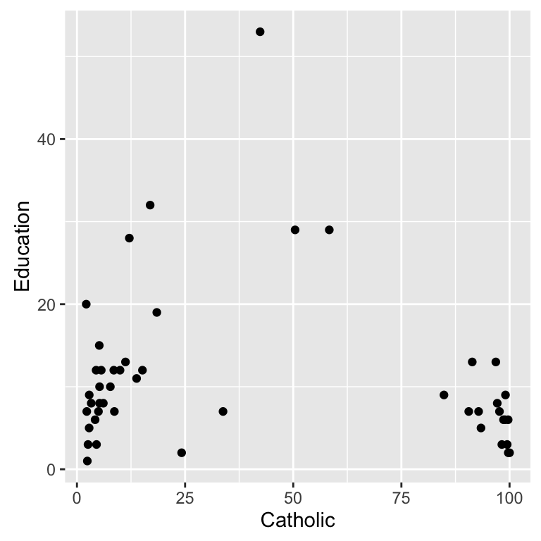

```r
ggplot(swiss, aes(x = Catholic, y = Education)) + geom_point()
```

# Cover Ass Better

```r
cor(swiss$Catholic, swiss$Education)
```

```
## [1] -0.1538589
```

# Fit Model

```r
mdl <- lm(Fertility ~ Catholic + Education, data=swiss)
summary(mdl)
```

```
##
## Call:
## lm(formula = Fertility ~ Catholic + Education, data = swiss)
##
## Residuals:
##     Min      1Q  Median      3Q     Max
## -15.042  -6.578  -1.431   6.122  14.322
##
## Coefficients:
##             Estimate Std. Error t value Pr(>|t|)
## (Intercept) 74.23369    2.35197  31.562  < 2e-16 ***
## Catholic     0.11092    0.02981   3.721  0.00056 ***
## Education   -0.78833    0.12929  -6.097 2.43e-07 ***
## ---
## Signif. codes:  0 '***' 0.001 '**' 0.01 '*' 0.05 '.' 0.1 ' ' 1
##
## Residual standard error: 8.331 on 44 degrees of freedom
## Multiple R-squared:  0.5745, Adjusted R-squared:  0.5552
## F-statistic:  29.7 on 2 and 44 DF,  p-value: 6.849e-09
```

# Partial F-Test

Let’s suppose a new model!

Fertility = $\beta_0$ + $\beta_1$ Education + $\beta_2$ Catholic + $\beta_3$ Infant.Mortality + $\epsilon$

Test hypothesis that $\beta_2 = \beta_3 = 0$.

# Partial F-Test

```r
reduced_mdl <- lm(Fertility ~ Education, data=swiss)
full_mdl <- lm(Fertility ~ Education + Catholic + Infant.Mortality, data=swiss)

# you can pass in two models!
anova(reduced_mdl, full_mdl)
```

```
## Analysis of Variance Table
##
## Model 1: Fertility ~ Education
## Model 2: Fertility ~ Education + Catholic + Infant.Mortality
##   Res.Df    RSS Df Sum of Sq      F    Pr(>F)
## 1     45 4015.2
## 2     43 2422.2  2      1593 14.139 1.909e-05 ***
## ---
## Signif. codes:  0 '***' 0.001 '**' 0.01 '*' 0.05 '.' 0.1 ' ' 1
```

Teeny-tiny p-value (look at all those asterisks) tells us $\beta_2$ and $\beta_3$ are not both zero, i.e. adding those variables was handy!

# Diversion…Get More Succinct!

What’s in an `anova()` ?

```r
anova_magic <- anova(reduced_mdl, full_mdl)

class(anova_magic)
```

```
## [1] "anova"      "data.frame"
```

```r
names(anova_magic)
```

```
## [1] "Res.Df"    "RSS"       "Df"        "Sum of Sq" "F"         "Pr(>F)"
```

```r
anova_magic[["Pr(>F)"]]
```

```
## [1]           NA 1.909423e-05
```

# Multiple Linear Regression…with interaction!

Let’s revise the additive model we fit earlier (Fertility = $\beta_0$ + $\beta_1$ Catholic + $\beta_2$ Education + $\epsilon$).

We’re curious:

As Education changes, does the effect of Catholic on Fertility change?

As Catholic changes, does the effect of Education on Fertility change?

# Fit the Model with Interaction Term

Fertility = $\beta_0$ + $\beta_1$ Catholic + $\beta_2$ Education + $\beta_3$ Catholic*Education + $\epsilon$

```r
mdl <- lm(Fertility ~ Catholic + Education + Catholic*Education, data=swiss) # yay
mdl <- lm(Fertility ~ Catholic + Education + Catholic:Education, data=swiss) # yay
mdl <- lm(Fertility ~ Catholic*Education, data=swiss) # yay
# mdl <- lm(Fertility ~ Catholic:Education, data=swiss) <-- NO, includes no additive terms
```

# Summarize Model

```r
summary(mdl)
```

```
##
## Call:
## lm(formula = Fertility ~ Catholic * Education, data = swiss)
##
## Residuals:
##     Min      1Q  Median      3Q     Max
## -11.953  -6.319  -1.368   6.380  14.297
##
## Coefficients:
##                     Estimate Std. Error t value Pr(>|t|)
## (Intercept)        70.937553   3.106471  22.835  < 2e-16 ***
## Catholic            0.184003   0.054539   3.374  0.00158 **
## Education          -0.427637   0.260176  -1.644  0.10754
## Catholic:Education -0.009380   0.005904  -1.589  0.11942
## ---
## Signif. codes:  0 '***' 0.001 '**' 0.01 '*' 0.05 '.' 0.1 ' ' 1
##
## Residual standard error: 8.191 on 43 degrees of freedom
## Multiple R-squared:  0.5981, Adjusted R-squared:  0.5701
## F-statistic: 21.33 on 3 and 43 DF,  p-value: 1.286e-08
```

# Looks Shoddy…Let’s Explore Further

Recall our plot from earlier:

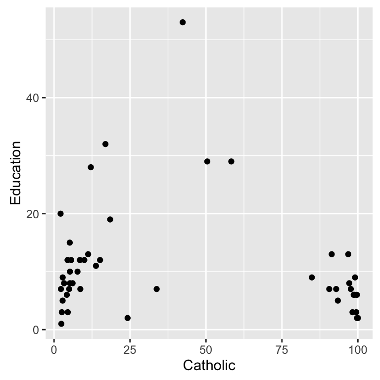

```r
ggplot(swiss, aes(x = Catholic, y = Education)) + geom_point()
```

Looks like Catholic is either very small or very big.

# A Little Manipulation

Let’s recode Catholic as a factor and see what happens.

```r
Catholic_median <- summary(swiss$Catholic)[["Median"]]

# install.packages('dplyr')
# install.packages('mosaic')
library(dplyr)
library(mosaic)

swiss_new <- swiss %>% mutate(
  Catholic_factor = derivedFactor(low = Catholic <= Catholic_median,
                           high = Catholic > Catholic_median))

head(swiss_new[c('Catholic', 'Catholic_factor')])
```

```
##   Catholic Catholic_factor
## 1     9.96             low
## 2    84.84            high
## 3    93.40            high
## 4    33.77            high
## 5     5.16             low
## 6    90.57            high
```

# Fit the New Model with Interaction

```r
mdl <- lm(Fertility ~ Catholic_factor*Education, data=swiss_new)
summary(mdl)
```

```
##
## Call:
## lm(formula = Fertility ~ Catholic_factor * Education, data = swiss_new)
##
## Residuals:
##      Min       1Q   Median       3Q      Max
## -15.2793  -6.9639  -0.8848   6.7463  14.9044
##
## Coefficients:
##                               Estimate Std. Error t value Pr(>|t|)
## (Intercept)                    71.2333     3.5081  20.305  < 2e-16 ***
## Catholic_factorhigh            14.3740     4.2755   3.362  0.00163 **
## Education                      -0.4226     0.3077  -1.373  0.17679
## Catholic_factorhigh:Education  -0.5914     0.3390  -1.745  0.08820 .
## ---
## Signif. codes:  0 '***' 0.001 '**' 0.01 '*' 0.05 '.' 0.1 ' ' 1
##
## Residual standard error: 8.365 on 43 degrees of freedom
## Multiple R-squared:  0.5808, Adjusted R-squared:  0.5516
## F-statistic: 19.86 on 3 and 43 DF,  p-value: 3.141e-08
```

# Working Example

```r
head(diamonds)
```

```
## Source: local data frame [6 x 10]
##
##   carat       cut  color clarity depth table price     x     y     z
##   (dbl)    (fctr) (fctr)  (fctr) (dbl) (dbl) (int) (dbl) (dbl) (dbl)
## 1  0.23     Ideal      E     SI2  61.5    55   326  3.95  3.98  2.43
## 2  0.21   Premium      E     SI1  59.8    61   326  3.89  3.84  2.31
## 3  0.23      Good      E     VS1  56.9    65   327  4.05  4.07  2.31
## 4  0.29   Premium      I     VS2  62.4    58   334  4.20  4.23  2.63
## 5  0.31      Good      J     SI2  63.3    58   335  4.34  4.35  2.75
## 6  0.24 Very Good      J    VVS2  62.8    57   336  3.94  3.96  2.48
```

- Fit a model to predict price using carat and another variable of your choosing.
- Now add an interaction term between carat and your other variable of choice!

# How We Did

```r
# ?diamonds

mdl1 <- lm(price ~ carat + x, data=diamonds)

mdl2 <- lm(price ~ carat*x, data=diamonds)

# anova(mdl1, mdl2)
# summary(mdl1)
# summary(mdl2)
```

# Logistic Regression

- Response variable is categorical
- But we are still considering a linear relationship!

# Logistic Regression

You can’t have a linear relationship between, say, age and gender.

But you can have a linear relationship between age and the log odds that someone is female.

Enter logit function:

$$\begin{equation}
\log \frac{p}{1-p} = \beta_0 + \beta_1 X_1 + \dots + \beta_n X_n
\end{equation}$$

$p$ = probability of “success”

$\log$$\frac{p}{1-p}$ = “log odds”

# The Data

```r
# ?UCBAdmissions
df <- as.data.frame(UCBAdmissions)
head(df)
```

```
##      Admit Gender Dept Freq
## 1 Admitted   Male    A  512
## 2 Rejected   Male    A  313
## 3 Admitted Female    A   89
## 4 Rejected Female    A   19
## 5 Admitted   Male    B  353
## 6 Rejected   Male    B  207
```

$p$ = probability of being admitted

$X_1$ = Gender

$X_2$ = Dept

# A Little Finagling

```r
# install.packages('reshape')
require(reshape)

# unravel
df <- untable(df[, c('Admit', 'Gender', 'Dept')], num=df[, 'Freq'])
rownames(df) <- seq(length=nrow(df))

# re-order levels of Admit
df <- mutate(df, Admit = relevel(Admit, 'Rejected'))

head(df) # 4526 rows now
```

```
##      Admit Gender Dept
## 1 Admitted   Male    A
## 2 Admitted   Male    A
## 3 Admitted   Male    A
## 4 Admitted   Male    A
## 5 Admitted   Male    A
## 6 Admitted   Male    A
```

# Training

Subset the data into training set (fit model) and testing set (test model).

```r
df_idx <- 1:nrow(df)
train_size <- floor(.8 * nrow(df))

train_idx <- sample(df_idx, size=train_size)
test_idx <- df_idx[!(df_idx %in% train_idx)]

train_df <- df[train_idx, ]
test_df <- df[test_idx, ]
```

# Fit the Model

`glm()` function (generalized linear model)

```r
mdl <- glm(Admit ~ Gender, family=binomial(link='logit'), data=train_df)

summary(mdl)
```

```
##
## Call:
## glm(formula = Admit ~ Gender, family = binomial(link = "logit"),
##     data = train_df)
##
## Deviance Residuals:
##     Min       1Q   Median       3Q      Max
## -1.0799  -1.0799  -0.8554   1.2782   1.5381
##
## Coefficients:
##              Estimate Std. Error z value Pr(>|z|)
## (Intercept)  -0.23383    0.04345  -5.382 7.37e-08 ***
## GenderFemale -0.58324    0.07131  -8.179 2.85e-16 ***
## ---
## Signif. codes:  0 '***' 0.001 '**' 0.01 '*' 0.05 '.' 0.1 ' ' 1
##
## (Dispersion parameter for binomial family taken to be 1)
##
##     Null deviance: 4831.0  on 3619  degrees of freedom
## Residual deviance: 4762.6  on 3618  degrees of freedom
## AIC: 4766.6
##
## Number of Fisher Scoring iterations: 4
```

# Interpret Coefficients

Recall: The model fits $\log \frac{p}{1-p} = \beta_0 + \beta_1 X_1$.

$\beta_0$ = -0.2338344

$\beta_1$ = -0.5832361

```r
coef(mdl)
```

```
##  (Intercept) GenderFemale
##   -0.2338344   -0.5832361
```

When applicant is male, $X_1$ = 0 and the log odds of admission are equal to the intercept.

We expect the log odds of admission to increase by -0.5832361 when applicant is female.

# Multiple Logistic Regression

```r
# pro tip: a period includes all variables as predictors
mdl <- glm(Admit ~ ., family=binomial(link='logit'), data=train_df)

summary(mdl)
```

```
##
## Call:
## glm(formula = Admit ~ ., family = binomial(link = "logit"), data = train_df)
##
## Deviance Residuals:
##     Min       1Q   Median       3Q      Max
## -1.4876  -0.9335  -0.3588   0.9452   2.4077
##
## Coefficients:
##              Estimate Std. Error z value Pr(>|z|)
## (Intercept)   0.57414    0.07595   7.560 4.04e-14 ***
## GenderFemale  0.13073    0.09046   1.445    0.148
## DeptB        -0.05398    0.12294  -0.439    0.661
## DeptC        -1.30983    0.11876 -11.029  < 2e-16 ***
## DeptD        -1.28987    0.11803 -10.928  < 2e-16 ***
## DeptE        -1.73901    0.13919 -12.494  < 2e-16 ***
## DeptF        -3.41593    0.19760 -17.287  < 2e-16 ***
## ---
## Signif. codes:  0 '***' 0.001 '**' 0.01 '*' 0.05 '.' 0.1 ' ' 1
##
## (Dispersion parameter for binomial family taken to be 1)
##
##     Null deviance: 4831.0  on 3619  degrees of freedom
## Residual deviance: 4134.6  on 3613  degrees of freedom
## AIC: 4148.6
##
## Number of Fisher Scoring iterations: 5
```

Simpson’s Paradox!

# Receiver Operating Characteristic Curve

a.k.a the illustrious ROC Curve

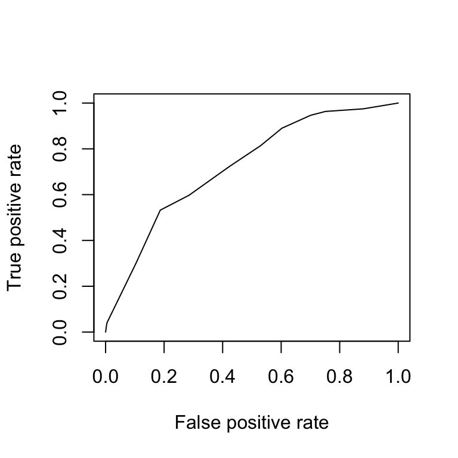

```r
#install.packages('ROCR')
library(ROCR)

prob_admit <- predict(mdl, newdata=test_df, type="response")
truth_admit <- test_df$Admit
pred <- prediction(prob_admit, truth_admit, label.ordering=c('Rejected', 'Admitted'))
perf <- performance(pred, "tpr", "fpr")
plot(perf)
```

### Area Under the Curve (AUC)

```r
auc.tmp <- performance(pred, "auc")
auc <- as.numeric(auc.tmp@y.values)
auc
```

```
## [1] 0.7237571
```

# Working Example

Run me:

```r
diamonds_new <- diamonds %>%
      mutate(bling = derivedFactor(no = price <= 5000,
          yes = price > 5000))
```

Use `glm()` with the `diamonds_new` data you just defined to fit a logistic regression where:

- we are predicting the probability of bling
- using predictor depth

# Our Approach

```r
mdl <- glm(bling ~ depth, family=binomial(link='logit'), data=diamonds_new)
summary(mdl)
```

```
##
## Call:
## glm(formula = bling ~ depth, family = binomial(link = "logit"),
##     data = diamonds_new)
##
## Deviance Residuals:
##     Min       1Q   Median       3Q      Max
## -0.9085  -0.8001  -0.7950   1.5959   1.6777
##
## Coefficients:
##              Estimate Std. Error z value Pr(>|z|)
## (Intercept)  0.037094   0.416643   0.089   0.9291
## depth       -0.016482   0.006747  -2.443   0.0146 *
## ---
## Signif. codes:  0 '***' 0.001 '**' 0.01 '*' 0.05 '.' 0.1 ' ' 1
##
## (Dispersion parameter for binomial family taken to be 1)
##
##     Null deviance: 63219  on 53939  degrees of freedom
## Residual deviance: 63213  on 53938  degrees of freedom
## AIC: 63217
##
## Number of Fisher Scoring iterations: 4
```

# Clustering

This is a classification task that seeks to group items in a way that:

1. Minimizes variance within groups
2. Maximizes distance between groups

Here, we will use the `kmeans()` function to implement k-means clustering. This is an unsupervised (a.k.a. the model doesn’t learn from ground truth labels) clustering algorithm that identifies $k$ group “centers” and assigns each data point to the group with the nearest centroid.

# Data

```r
# I'm sorry
head(iris)
```

```
##   Sepal.Length Sepal.Width Petal.Length Petal.Width Species
## 1          5.1         3.5          1.4         0.2  setosa
## 2          4.9         3.0          1.4         0.2  setosa
## 3          4.7         3.2          1.3         0.2  setosa
## 4          4.6         3.1          1.5         0.2  setosa
## 5          5.0         3.6          1.4         0.2  setosa
## 6          5.4         3.9          1.7         0.4  setosa
```

Do a little scrubbing.

```r
df <- iris[, c('Sepal.Length', 'Sepal.Width', 'Petal.Length', 'Petal.Width')]
df <- na.omit(df)
df <- scale(df)
```

# Determine Number of Clusters

Elbow Method: Identify the number of clusters at which the sums of squared errors within groups drops.

```r
set.seed(1)
col_variance <- apply(df, 2, var)

# sum squared error for only 1 group
weighted_ss <- (nrow(df)-1)*sum(col_variance)

for (i in 2:15) {
  within_cluster_ss <- kmeans(df, centers=i)$withinss
  weighted_ss[i] <- sum(within_cluster_ss)
}
```

# Voila, Elbow

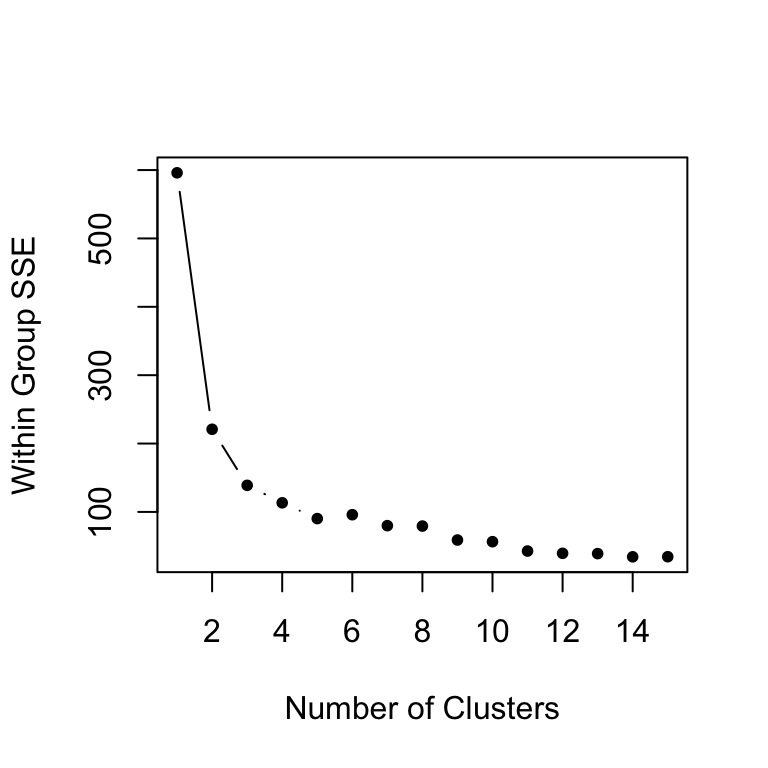

```r
plot(1:15, weighted_ss, pch=20, type="b", xlab="Number of Clusters", ylab="Within Group SSE")
```

# Implement K-Means

```r
fit <- kmeans(df, centers=3)

aggregate(df, by=list(fit$cluster), FUN=mean)
```

```
##   Group.1 Sepal.Length Sepal.Width Petal.Length Petal.Width
## 1       1  -1.01119138  0.85041372   -1.3006301  -1.2507035
## 2       2   1.13217737  0.08812645    0.9928284   1.0141287
## 3       3  -0.05005221 -0.88042696    0.3465767   0.2805873
```

# How Did We Do?

We implemented unsupervised clustering, but…the iris data set has a species column. Let’s consider that ground truth for our clusters and compare with the k-means results.

```r
df <- data.frame(df, Fit=fit$cluster)
df$Fit <- as.factor(df$Fit)
df["Species"] <- iris$Species

tbl <- table(df$Fit, df$Species)
print(tbl)
```

```
##
##     setosa versicolor virginica
##   1     50          0         0
##   2      0         11        36
##   3      0         39        14
```

# Confusion Matrix

```r
# install.packages('plyr')
require(plyr)

df <- df %>% mutate(Fit = revalue(Fit,
        c('1' = 'setosa', '2' = 'virginica', '3' = 'versicolor')))

#install.packages('caret')
#install.packages('e1071')
require(caret)
require(e1071)

confusionMatrix(df$Fit, df$Species)
```

```
## Confusion Matrix and Statistics
##
##             Reference
## Prediction   setosa versicolor virginica
##   setosa         50          0         0
##   versicolor      0         39        14
##   virginica       0         11        36
##
## Overall Statistics
##
##                Accuracy : 0.8333
##                  95% CI : (0.7639, 0.8891)
##     No Information Rate : 0.3333
##     P-Value [Acc > NIR] : < 2.2e-16
##
##                   Kappa : 0.75
##  Mcnemar's Test P-Value : NA
##
## Statistics by Class:
##
##                      Class: setosa Class: versicolor Class: virginica
## Sensitivity                 1.0000            0.7800           0.7200
## Specificity                 1.0000            0.8600           0.8900
## Pos Pred Value              1.0000            0.7358           0.7660
## Neg Pred Value              1.0000            0.8866           0.8641
## Prevalence                  0.3333            0.3333           0.3333
## Detection Rate              0.3333            0.2600           0.2400
## Detection Prevalence        0.3333            0.3533           0.3133
## Balanced Accuracy           1.0000            0.8200           0.8050
```

# Thanks!

deirdrefitzpatrick@massmutual.com

dudwin@massmutual.com

[figure not shown]

(chat with us about MassMutual Data Labs + our data science development program located in Amherst)